# rpp1

zchen

September 18, 2015

Download data, unzip and load into R

```r
download.file("https://d396qusza40orc.cloudfront.net/repdata%2Fdata%2Factivity.zip",
              destfile="act.zip", method="libcurl")
unzip("act.zip")
act <- read.csv("activity.csv")
```

What is mean total number of steps taken per day?

Calculate total steps for each day, then make a hitogram of the daily steps, report mean and median of daily steps.

The mean and median of daily steps are 10766 and 10765, respectively.

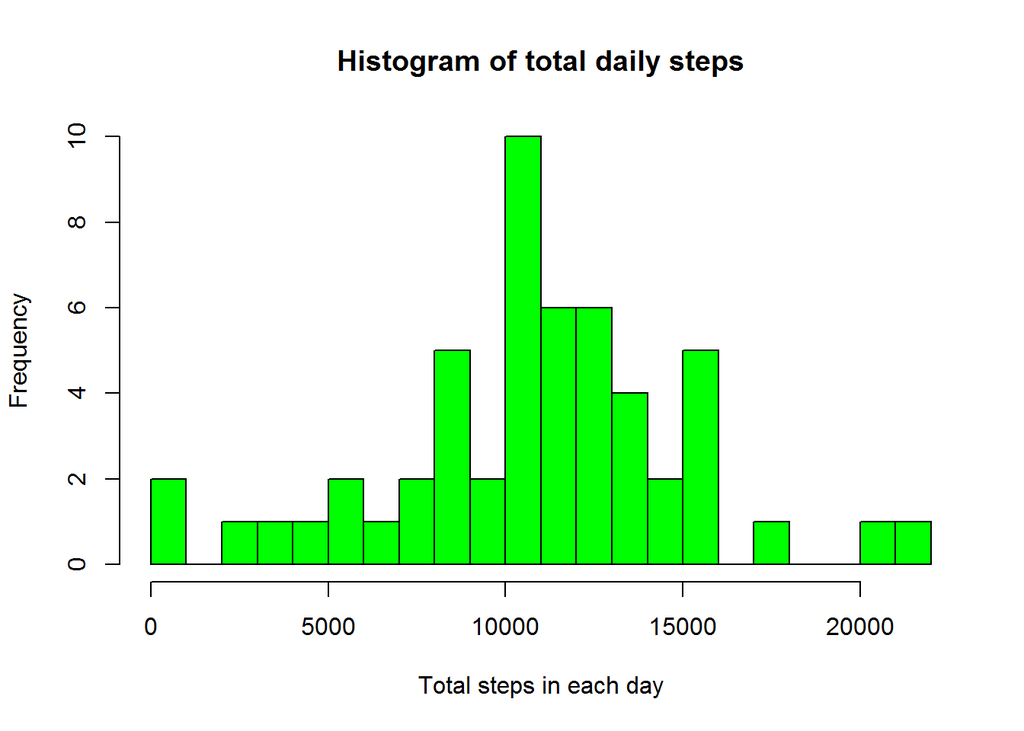

```r
daysum1 <- tapply(act$steps, act$date, sum)
hist(daysum1, breaks=22, col="green", xlab="Total steps in each day",
     main="Histogram of total daily steps")
```

```r
mean(daysum1, na.rm=TRUE)
```

```
## [1] 10766.19
```

```r
median(daysum1, na.rm=TRUE)
```

```
## [1] 10765
```

What is the average daily activity pattern? The maximum number of steps are from 8:35 (206 steps) in the morning.

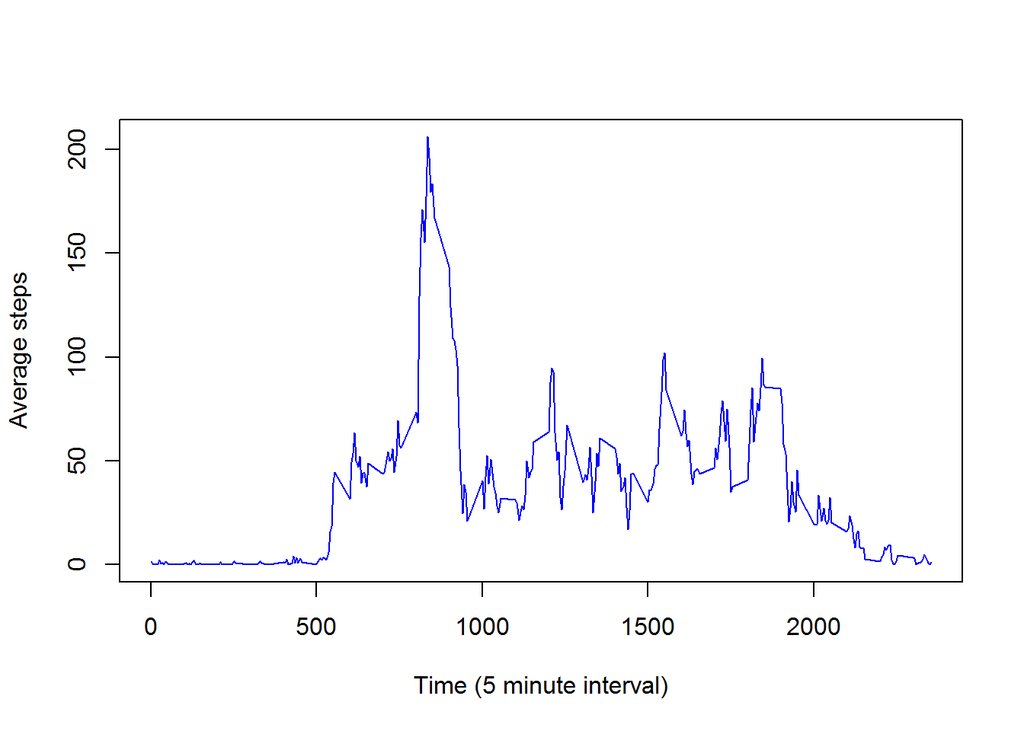

```r
avginterv <- tapply(act$steps, act$interval, mean, na.rm=TRUE)
plot(names(avginterv), avginterv, type="l", xlab="Time (5 minute interval)", ylab="Average steps", col="blue")
```

```r
tail(sort(avginterv),1)
```

```
##      835
## 206.1698
```

Imputing missing values Total number of missing values is 2304.

Asign average number of steps of 5 minute interval to corresponding 5 minute interval of the days with missing values. The mean and median of the new data set are 10765.6 and 10762, respectively, very close to the values before imputation.

```r
sum(is.na(act$steps))
```

```
## [1] 2304
```

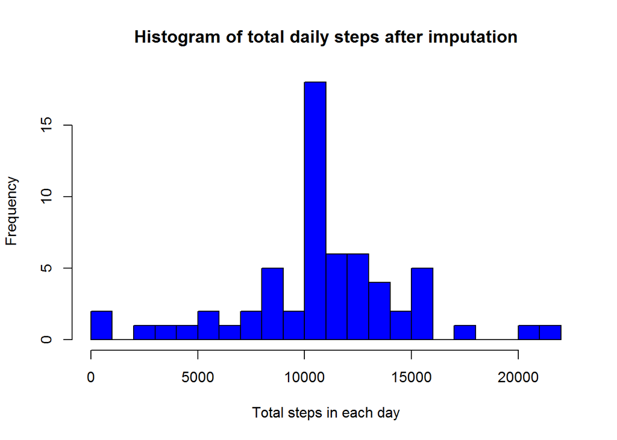

```r
subset(act, is.na(steps)) -> actna
subset(act, !is.na(steps)) -> act1
tapply(act1$steps, act1$interval, mean, na.rm=TRUE) -> intvm
for (i in c(names(intvm))) {
    actna[actna$interval==i,]$steps <- round(intvm[[i]], 0)
}
act2 <- rbind(act1, actna)
daysum2 <- tapply(act2$steps, act2$date, sum)
hist(daysum2, breaks=22, col="blue", xlab="Total steps in each day",
     main="Histogram of total daily steps after imputation")
```

```r
mean(daysum2, na.rm=TRUE)
```

```
## [1] 10765.64
```

```r
median(daysum2, na.rm=TRUE)
```

```
## [1] 10762
```

Are there differences in activity patterns between weekdays and weekends? Split the imputed dataset into two, based on whether the date is weekday or weekend. Then generate average daily steps for weekday and weekend, respectively, and make histograms for the two daily average steps of 5 minute interval.

It seems clear that more people get up earlier on weekdays (around 6 am) than weekend days and more people sleep late during weekend than weekdays.

```r
library(dplyr)
```

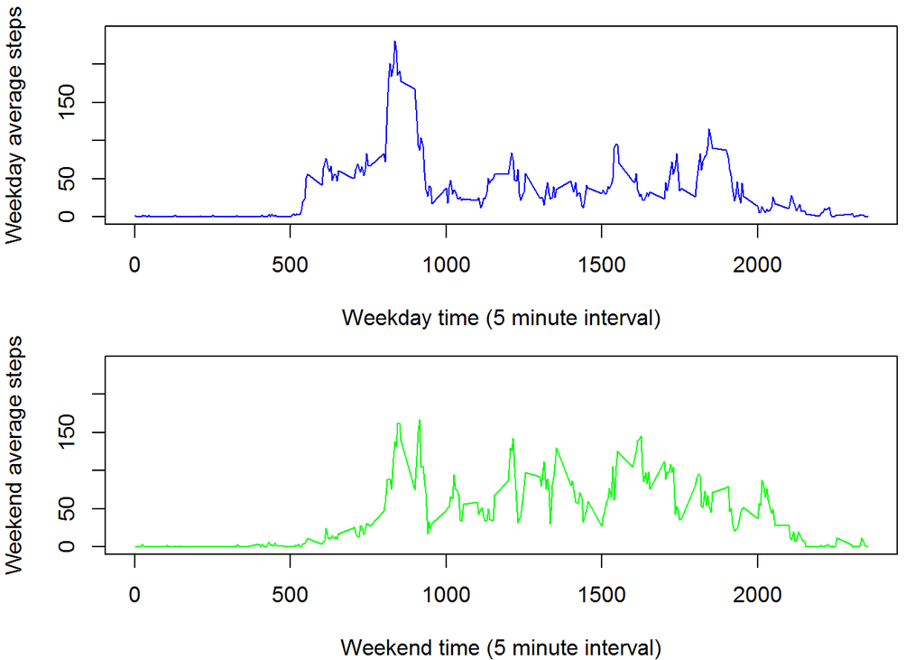

```r
act2 <- mutate(act2, weekday=weekdays(as.Date(act2$date)))
act2$weekday <- ifelse(act2$weekday=="Saturday", "weekend", act2$weekday)
act2$weekday <- ifelse(act2$weekday=="Sunday", "weekend", act2$weekday)
act2$weekday <- ifelse(act2$weekday!="weekend", "weekday", act2$weekday)

act2weekday <- subset(act2, act2$weekday=="weekday")
act2weekend <- subset(act2, act2$weekday=="weekend")

## make hitograms
par(mfrow=c(2,1),mar=c(4,4,1,1))
avgintervweekday <- tapply(act2weekday$steps, act2weekday$interval, mean, na.rm=TRUE)
plot(names(avgintervweekday), avgintervweekday, type="l", xlab="Weekday time (5 minute interval)", ylab="Weekday average steps", col="blue", ylim=c(0,240))

avgintervweekend <- tapply(act2weekend$steps, act2weekend$interval, mean, na.rm=TRUE)
plot(names(avgintervweekend), avgintervweekend, type="l", xlab="Weekend time (5 minute interval)", ylab="Weekend average steps", col="green", ylim=c(0,240))
```